# Math1318_Time Series_Assignment_1

2022-03-25

# Problem statement:

Analyzing the changes in the closing price of a share in ASX available here Download here data set is composed of 144 observations out of a possible 252 trading days in a year and all the points are collected in the same year and on consecutive trading days)

## Table of contents:

1. Calling important libraries
2. Inserting data and converting into time series
3. A descriptive analysis to know the data and inform further modelling
4. Looking for 1- Trend; 2- Seasonality; 3- Changing variance; 4- Behavior; 5- Change point.
5. Fitting different models linear, quadratic, seasonal and harmonic
6. Conclusion: Interpretation of result.

# Important libraries

```r
library(readr)  #reading csv file
library(TSA)    # for time series data
library(tseries) # for Automatic Time Series Forecasting:
library(forecast) # for Forecasting
```

## Processing data into R

```r
# Reading the file in R
ASX <- read.csv("assignment1Data2022.csv")

# Checking the class of the dataset
class(ASX)
```

```
## [1] "data.frame"
```

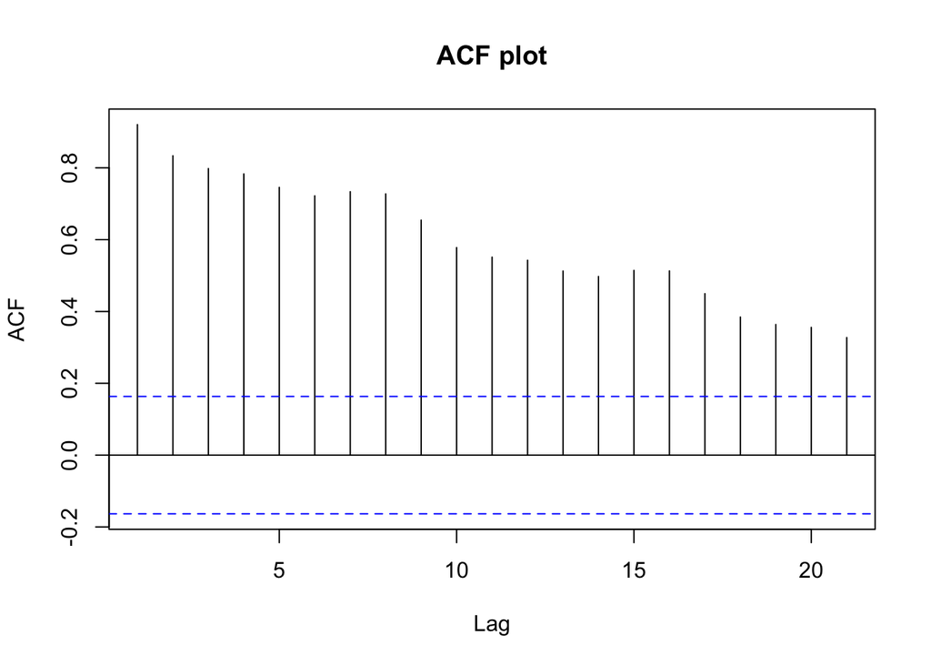

```r
ASX1 <- ts(ASX$x)
acf(ASX1, main = "ACF plot")
```

```r
ASX1 <- ts(ASX$x, frequency=7)
#acf(ASX1, main = "ACF of standardized residuals.")
# Making sure the data is a class of time series
class(ASX1)
```

```
## [1] "ts"
```

```r
summary(ASX1)
```

```
##    Min. 1st Qu.  Median    Mean 3rd Qu.    Max.
##   15.47   71.33   81.25   75.41   85.05   95.48
```

Used acf plot for finding frequncy, the wave is repeating after each 7 lags. so considering frequency=7

## Looking for–> 1- Trend; 2- Seasonality; 3- Changing variance; 4- Behavior; 5- Change point.

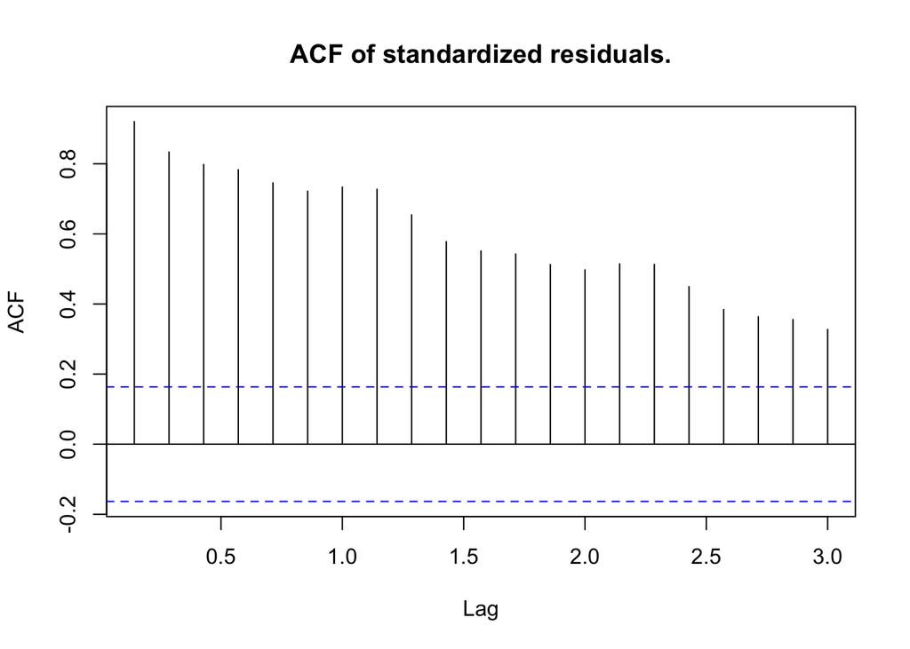

```r
acf(ASX1, main = "ACF of standardized residuals.")
```

```r
# Making sure the data is a class of time series
class(ASX1)
```

```
## [1] "ts"
```

```r
summary(ASX1)
```

```
##    Min. 1st Qu.  Median    Mean 3rd Qu.    Max.
##   15.47   71.33   81.25   75.41   85.05   95.48
```

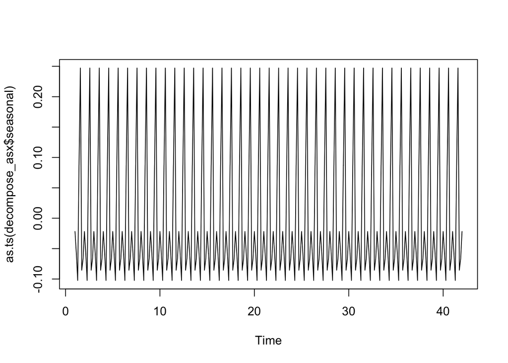

```r
# using Decomposition for a cleaner way to understand trends.
# when we look at the plots, its quite clear that observations are different at particular time , so data is not seasonal. It a cyclical
#checking trends and seasnality after decomping
ts_asx = ts(ASX, frequency = 7)
decompose_asx = decompose(ts_asx, "additive")
plot(as.ts(decompose_asx$seasonal))
```

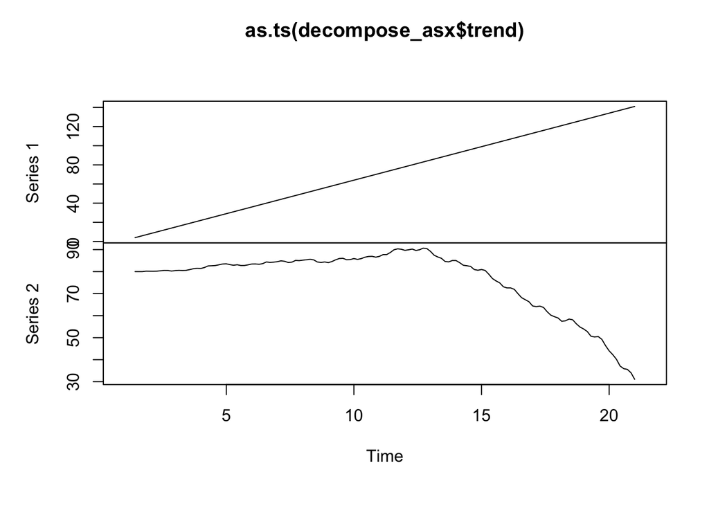

```r
plot(as.ts(decompose_asx$trend))
```

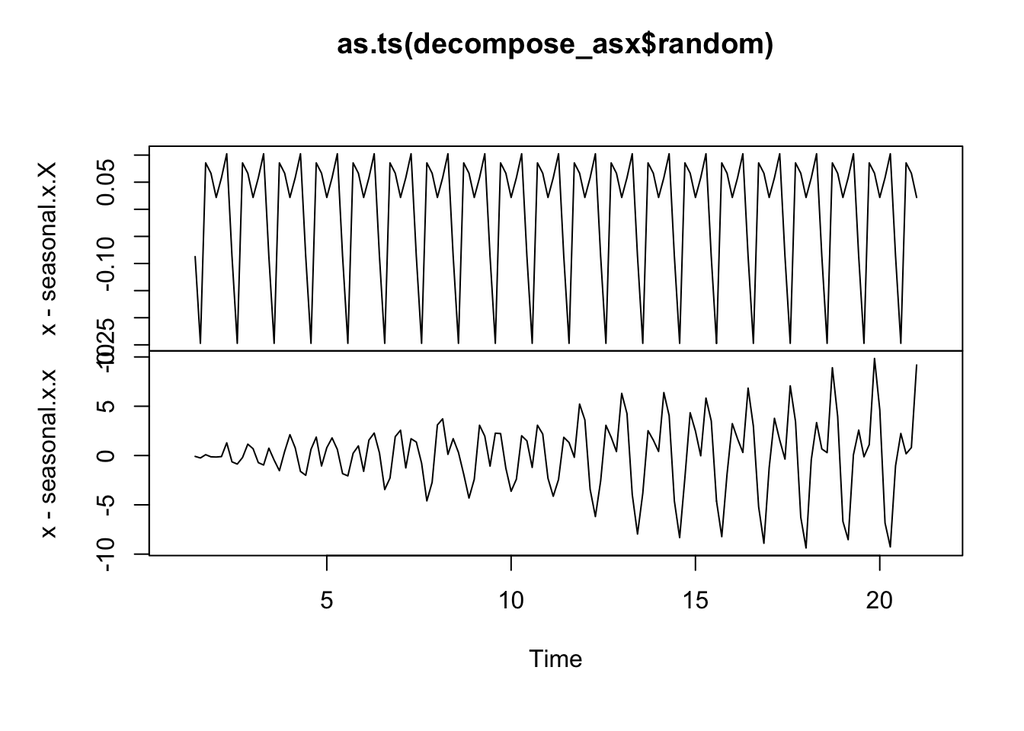

```r
plot(as.ts(decompose_asx$random))
```